# Using Turnstile Data To Forcast Student Worker Staffing

Chad Madding, Shane Weinstock

March 12, 2020

**Deliverables:**

**EDA:**

Saturday March 21 at 11:59pm

**Deliverable:**

1. 3-minute YouTube video: (You can use the same slides but each team member must make the full presentation with all the slides.)
   1. Identify yourself and your team (if applicable).
   2. Describe Data Set / Time Series (Who, What, When, Where, Why and How)
   3. Stationary / Non-Stationary
   4. ACFs and Spectral Densities just to explore
   5. At least 2 candidate ARMA / ARIMA models
      1. The models in factored form or at least separate the stationary and non-stationary factors with standard deviation or variance of the white noise.
      2. AIC
      3. ASE
      4. Visualization of Forecasts with a Practical Horizon.
      5. Strategy / Plans for the rest of the analysis.
2. Submit your slides to 2DS and make sure your video URL is on the Google Doc.

### Describe Data Set

#### Time Series (Who, What, When, Where, Why and How)

**Read in the data**

```r
#Read in the data
SMUSwipe <- read_excel("AnonDataTurnstile.xlsx")
```

**Data Cleaning**

Compactly Display the Structure of the data.

```
## Classes 'tbl_df', 'tbl' and 'data.frame':    414155 obs. of  4 variables:
##  $ LDT                  : POSIXct, format: "2019-01-02 06:00:08" "2019-01-02 06:00:33" ...
##  $ Message Type         : chr  "CardAdmitted" "CardAdmitted" "CardAdmitted" "CardAdmitted" ...
##  $ ID#                  : num  4272 1325 2551 253 257 ...
##  $ Secondary Object Name: chr  "DEDM (101.1LB)" "DEDM (101.3LB)" "DEDM (101.1LB)" "DEDM (101.2LB)" ...
```

```
## # A tibble: 6 x 9
##   LDT                 `Message Type` `ID#` `Secondary Obje~ Time  Day
##   <dttm>              <chr>          <dbl> <chr>            <chr> <chr>
## 1 2019-01-02 06:00:08 CardAdmitted    4272 DEDM (101.1LB)   06:0~ Wedn~
## 2 2019-01-02 06:00:33 CardAdmitted    1325 DEDM (101.3LB)   06:0~ Wedn~
## 3 2019-01-02 06:00:36 CardAdmitted    2551 DEDM (101.1LB)   06:0~ Wedn~
## 4 2019-01-02 06:00:51 CardAdmitted     253 DEDM (101.2LB)   06:0~ Wedn~
## 5 2019-01-02 06:01:20 CardAdmitted     257 DEDM (101.2LB)   06:0~ Wedn~
## 6 2019-01-02 06:04:26 CardAdmitted    2546 DEDM (101.2LB)   06:0~ Wedn~
## # ... with 3 more variables: Date <date>, Hour <chr>, Hours <chr>
```

Hourly ID Swipes for all Turnstiles?

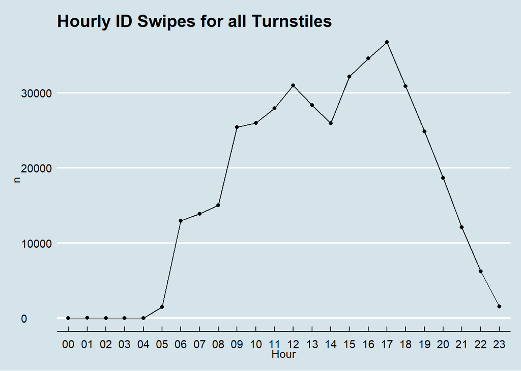

```r
#Group all badge swipes by the hour
df = count(SMUSwipe, Hours)
hourplot = count(SMUSwipe,Hour)

hourplot %>%
  ggplot(aes(x=Hour,y=n, group=1))+
  geom_line()+
  geom_point()+
  theme_economist()+
  scale_colour_economist()+
  ggtitle('Hourly ID Swipes for all Turnstiles')
```

What are the Daily ID Swipes for all Turnstiles?

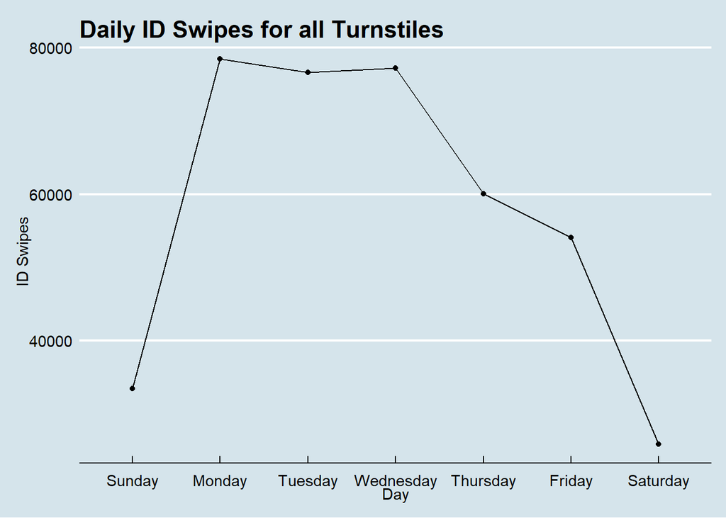

```r
dayCount=count(SMUSwipe, Day)
dayCount$Day <- factor(dayCount$Day, levels= c("Sunday", "Monday",
    "Tuesday", "Wednesday", "Thursday", "Friday", "Saturday"))

dayCount=dayCount[order(dayCount$Day), ]

dayCount %>%
  ggplot(aes(x=Day,y=n, group=1))+
  geom_line()+
  geom_point()+
  theme_economist()+
  scale_colour_economist()+
  theme_economist()+
  ggtitle('Daily ID Swipes for all Turnstiles')+
  ylab('ID Swipes')
```

We want to group all ID swipes by 15 minutes (quarter hour).

```r
#Group all ID swipes by 15 minutes (quarter hour)
SMUSwipe$Minutes <- format(SMUSwipe$LDT,"%M")
SMUSwipe$interval_15 <-ifelse(SMUSwipe$Minutes <= 15, 1, ifelse(SMUSwipe$Minutes <= 30, 2, ifelse(SMUSwipe$Minutes <= 45, 3, ifelse(SMUSwipe$Minutes <= 60, 4))))
SMUSwipe$Minutes_15<-paste(SMUSwipe$Hours, SMUSwipe$interval_15, sep=" ")
```

Create a data set for each turnstile.

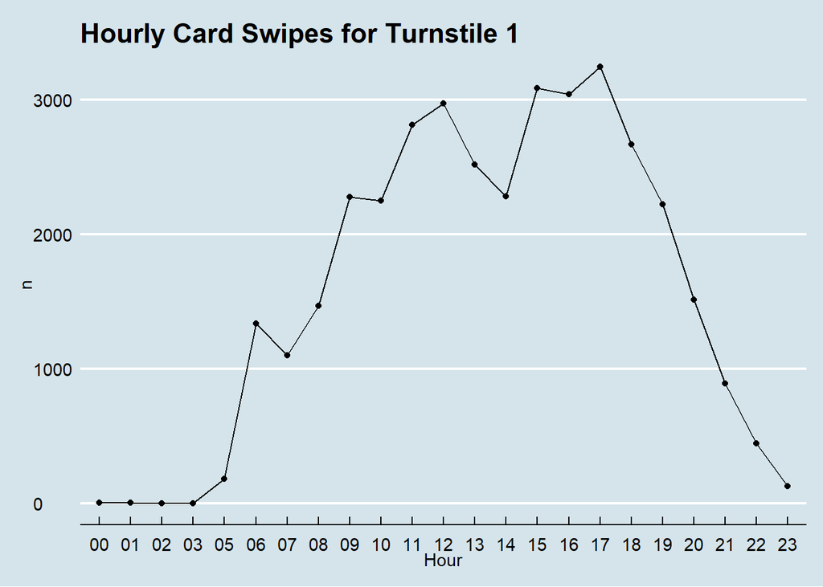

```r
#Create a dataset for each turnstyle
SMUSwipeTurn1 = SMUSwipe[SMUSwipe[,4]=="DEDM (101.1LB)",]
SMUSwipeTurn2 = SMUSwipe[SMUSwipe[,4]=="DEDM (101.2LB)",]
SMUSwipeTurn3 = SMUSwipe[SMUSwipe[,4]=="DEDM (101.3LB)",]

HTurn1 = count(SMUSwipeTurn1, Hour)
HTurn1 %>%
  ggplot(aes(x=Hour,y=n, group=1))+
  geom_line()+
  geom_point()+
  theme_economist()+
  scale_colour_economist()+
  ggtitle('Hourly Card Swipes for Turnstile 1')
```

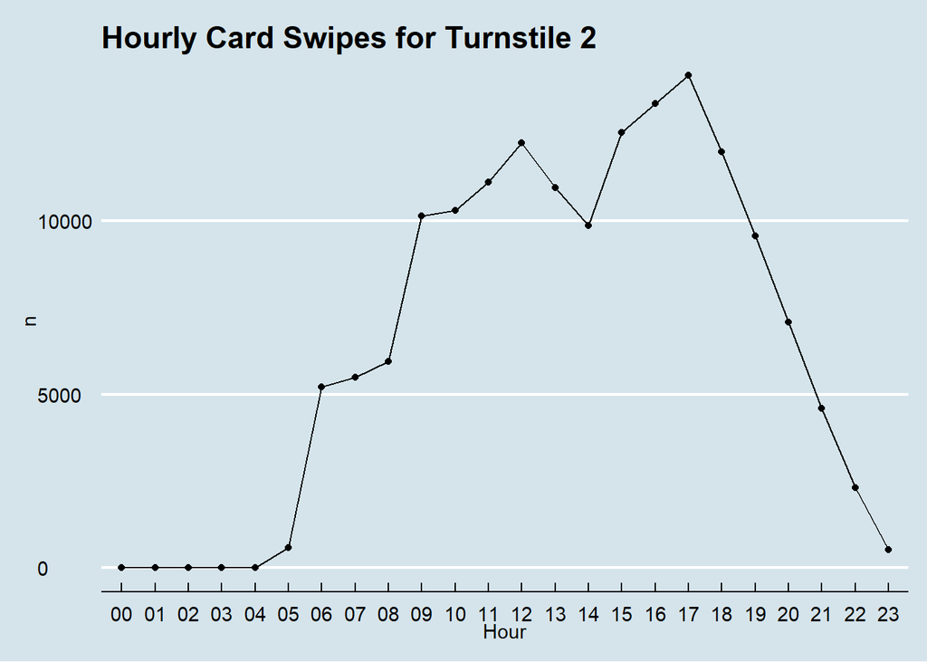

```r
HTurn2 = count(SMUSwipeTurn2, Hour)
HTurn2 %>%
  ggplot(aes(x=Hour,y=n, group=1))+
  geom_line()+
  geom_point()+
  theme_economist()+
  scale_colour_economist()+
  ggtitle('Hourly Card Swipes for Turnstile 2')
```

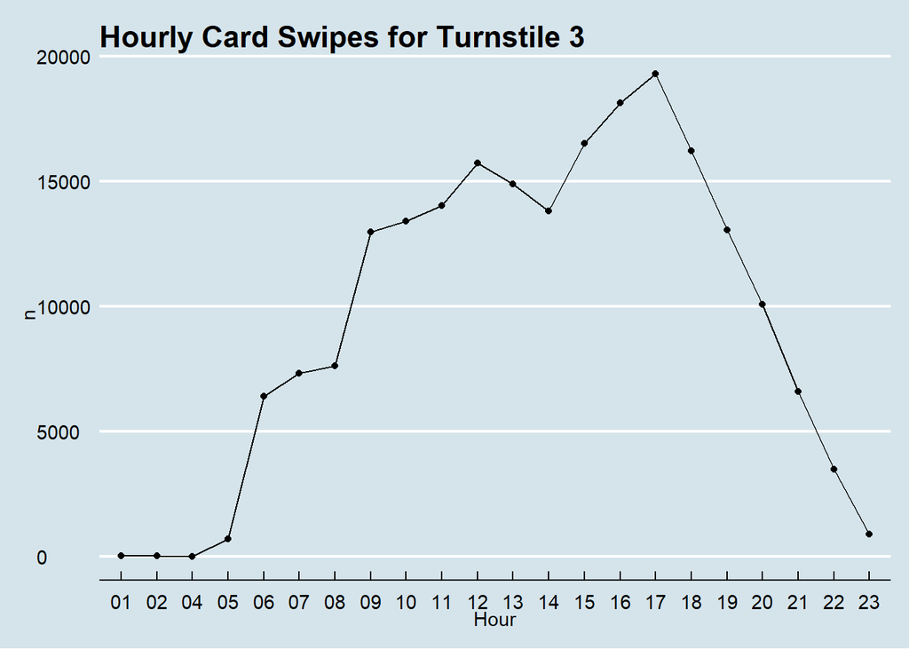

```r
HTurn3 = count(SMUSwipeTurn3, Hour)
HTurn3 %>%
  ggplot(aes(x=Hour,y=n, group=1))+
  geom_line()+
  geom_point()+
  theme_economist()+
  scale_colour_economist()+
  ggtitle('Hourly Card Swipes for Turnstile 3')
```

Looks like turnstile 3 gets used more than the others but the pattern of usage looks the same accross each.

This data is anamonized but we can still see who are some of the top users.

```r
#This will count up the times users swiped in.
IDCount = count(SMUSwipe, `ID#`)
#Print off the top 10 users ordering nuency in decending order
head(IDCount[order(IDCount$n, decreasing = TRUE),],10)
```

```
## # A tibble: 10 x 2
##    `ID#`     n
##    <dbl> <int>
##  1  1445   431
##  2  1168   421
##  3  1429   393
##  4  1469   372
##  5  1140   365
##  6   912   356
##  7  1778   351
##  8   104   346
##  9   152   343
## 10   214   335
```

Look at some user data.

```r
#Breakdown user numbers
summary(IDCount$n)
```

[output not shown]

```r
#how many uses
count(IDCount)
```

```
## # A tibble: 1 x 1
##       n
##   <int>
## 1 10910
```

Convert the hourly data to time series.

```r
#Hourley data
AnonDataTurnstile = ts(df$n)
```

#### Visualize what we have so far.

**Plot the hourly data for all three turnstyles**

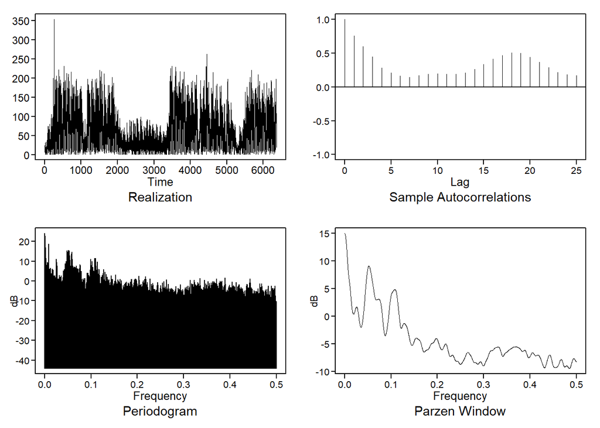

```r
#Plot the hourly data
TurnPlotHour=plotts.sample.wge(AnonDataTurnstile)
```

Start ID’ing the data by using the Box and Jeakins method with first differcing the data

```r
#Differcing the data to use the Box and Jeakins method
AnonDataTurnstile_diff=artrans.wge(AnonDataTurnstile,phi.tr=1)
```

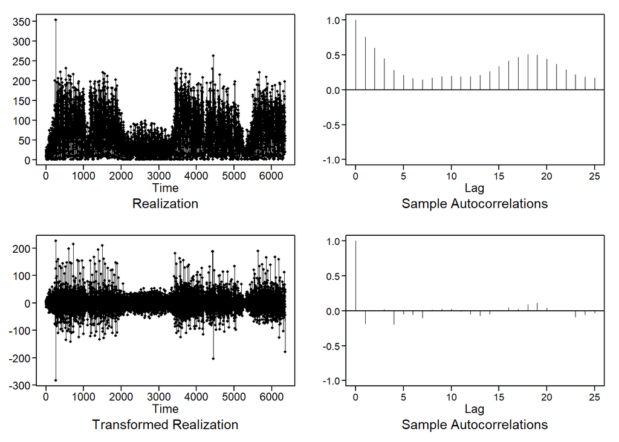

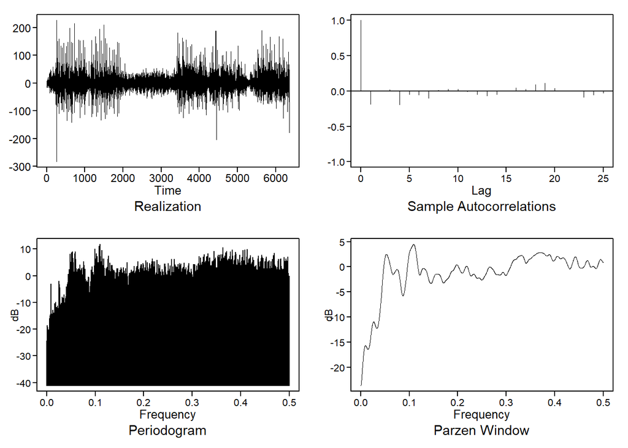

```r
#Plot the differeaced hourly data - diff
plotts.sample.wge(AnonDataTurnstile_diff)
```

Use aic5.wge() to identify estimates of p and q on the differanced data.

```r
#AIC of the hourly data
aic5.wge(AnonDataTurnstile_diff)
```

```
## ---------WORKING... PLEASE WAIT...
##
##
## Five Smallest Values of  aic
```

```
##       p    q        aic
## 14    4    1   6.772941
## 15    4    2   6.773180
## 17    5    1   6.773186
## 18    5    2   6.773561
## 11    3    1   6.809589
```

Use the estimate of p and q to get estimates of the phis and thetas.

```r
#Use the estimate of p and q to get estimates of the phis and thetas.
est = est.arma.wge(AnonDataTurnstile_diff, p = 4, q = 1)
```

```
##
## Coefficients of Original polynomial:
## 0.6258 0.1192 0.0058 -0.1950
##
## Factor                 Roots                Abs Recip    System Freq
## 1-1.3802B+0.5935B^2    1.1628+-0.5770i      0.7704       0.0733
## 1+0.7544B+0.3286B^2   -1.1479+-1.3135i      0.5732       0.3643
##
##
```

```r
#Use the estimated model to forecast and so on.
phi=est$phi
phi
```

```
## [1]  0.625770409  0.119172242  0.005786366 -0.195033296
```

```r
theta=est$theta
theta
```

```
## [1] 0.9735967
```

```r
wnv=est$avar
wnv
```

```
## [1] 872.2307
```

#### Final ARMA Model

$$(1-B)(1-0.626B-0.119B^2-0.006B^3+0.195B^4)X_t=(1-0.973B)a_t\ \sigma^2_a=872.23$$

```r
#forcast hour
foreHour_diff=fore.arma.wge(AnonDataTurnstile_diff, phi = est$phi, theta = est$theta, lastn = T, n.ahead = 48, limits=F)
```

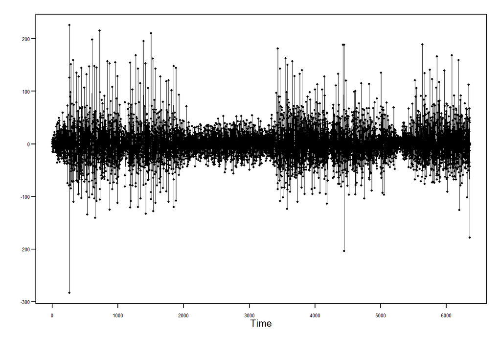

#### Seasonal Model

Lets see what a Seasonal Model might look like

Look at the data again.

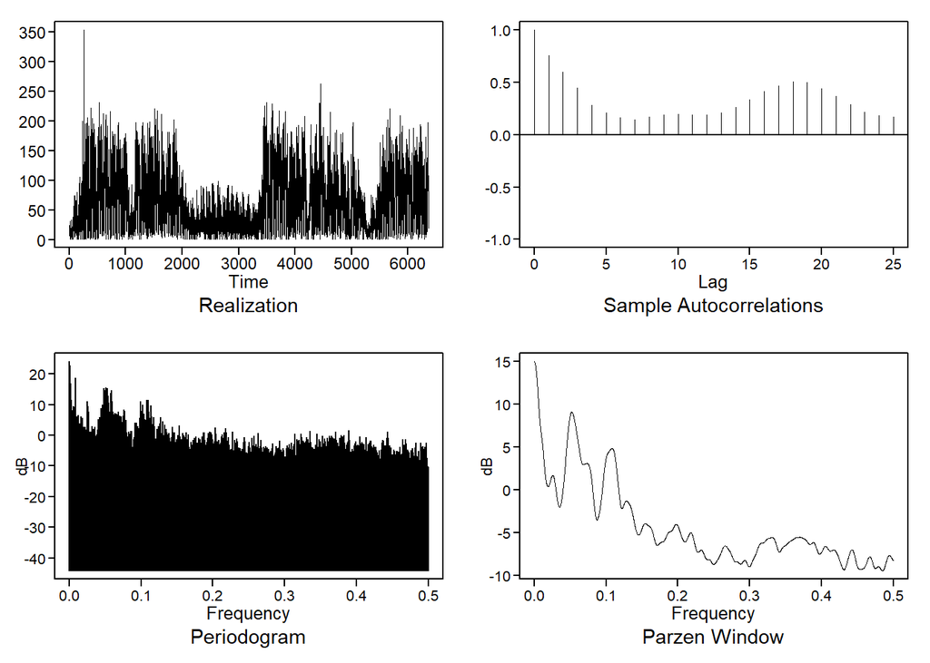

```r
plotts.sample.wge(AnonDataTurnstile)
```

There are a few peeks we can look at for a sign of seasonality in the data.  
This data is from a collage so we might expect to find a nine month pattern accounting for the three months of Summer break.  
We found the factors at 36 seemed to match up. This would coinside with a 9 month weekly pattern.

```r
#Factor tables
factAnonData=est.ar.wge(AnonDataTurnstile,p=36,type='burg')
```

```
##
## Coefficients of Original polynomial:
## 0.5989 0.1287 0.0209 -0.1696 0.0448 -0.0018 -0.0514 0.0468 0.0451 0.0142 -0.0322 -0.0150 -0.0005 0.0419 0.0732 0.0485 0.0014 0.0781 0.0660 -0.0179 -0.0217 0.0323 -0.0348 -0.0038 0.0198 0.0198 0.0038 -0.0197 -0.0012 0.0178 -0.0099 -0.0154 -0.0578 0.0106 -0.0252 0.0866
##
## Factor                 Roots                Abs Recip    System Freq
## 1-0.9875B              1.0127               0.9875       0.0000
## 1-1.8456B+0.9524B^2    0.9690+-0.3334i      0.9759       0.0527
## 1-1.5295B+0.9522B^2    0.8032+-0.6365i      0.9758       0.1067
## 1-0.6566B+0.8946B^2    0.3670+-0.9915i      0.9458       0.1936
## 1+0.9431B             -1.0604               0.9431       0.5000
## 1-1.6817B+0.8873B^2    0.9477+-0.4785i      0.9419       0.0744
## 1-0.9915B+0.8841B^2    0.5607+-0.9037i      0.9403       0.1616
## 1-1.2654B+0.8826B^2    0.7169+-0.7868i      0.9395       0.1324
## 1+1.5945B+0.8765B^2   -0.9096+-0.5600i      0.9362       0.4122
## 1+1.7486B+0.8753B^2   -0.9989+-0.3804i      0.9356       0.4421
## 1+1.8340B+0.8702B^2   -1.0537+-0.1969i      0.9329       0.4706
## 1-0.3436B+0.8699B^2    0.1975+-1.0539i      0.9327       0.2205
## 1+0.8875B+0.8652B^2   -0.5129+-0.9449i      0.9302       0.3291
## 1+1.1842B+0.8632B^2   -0.6859+-0.8294i      0.9291       0.3600
## 1+1.3812B+0.8571B^2   -0.8058+-0.7194i      0.9258       0.3840
## 1+0.2623B+0.8492B^2   -0.1544+-1.0741i      0.9215       0.2727
## 1+0.6293B+0.8255B^2   -0.3812+-1.0325i      0.9086       0.3063
## 1+0.0034B+0.8003B^2   -0.0021+-1.1178i      0.8946       0.2503
## 1-1.7655B+0.7939B^2    1.1120+-0.1522i      0.8910       0.0216
##
##
```

```r
factor.wge(c(rep(0,35),1)) #(1-B^36)
```

```
##
## Coefficients of Original polynomial:
## 0.0000 0.0000 0.0000 0.0000 0.0000 0.0000 0.0000 0.0000 0.0000 0.0000 0.0000 0.0000 0.0000 0.0000 0.0000 0.0000 0.0000 0.0000 0.0000 0.0000 0.0000 0.0000 0.0000 0.0000 0.0000 0.0000 0.0000 0.0000 0.0000 0.0000 0.0000 0.0000 0.0000 0.0000 0.0000 1.0000
##
## Factor                 Roots                Abs Recip    System Freq
## 1-1.9696B+1.0000B^2    0.9848+-0.1736i      1.0000       0.0278
## 1-1.0000B+1.0000B^2    0.5000+-0.8660i      1.0000       0.1667
## 1+1.0000B             -1.0000               1.0000       0.5000
## 1+1.5321B+1.0000B^2   -0.7660+-0.6428i      1.0000       0.3889
## 1-1.2856B+1.0000B^2    0.6428+-0.7660i      1.0000       0.1389
## 1-1.7321B+1.0000B^2    0.8660+-0.5000i      1.0000       0.0833
## 1-1.5321B+1.0000B^2    0.7660+-0.6428i      1.0000       0.1111
## 1-0.3473B+1.0000B^2    0.1736+-0.9848i      1.0000       0.2222
## 1+1.2856B+1.0000B^2   -0.6428+-0.7660i      1.0000       0.3611
## 1+0.3473B+1.0000B^2   -0.1736+-0.9848i      1.0000       0.2778
## 1-1.0000B              1.0000               1.0000       0.0000
## 1+1.0000B+1.0000B^2   -0.5000+-0.8660i      1.0000       0.3333
## 1-1.8794B+1.0000B^2    0.9397+-0.3420i      1.0000       0.0556
## 1-0.6840B+1.0000B^2    0.3420+-0.9397i      1.0000       0.1944
## 1+0.0000B+1.0000B^2    0.0000+-1.0000i      1.0000       0.2500
## 1+0.6840B+1.0000B^2   -0.3420+-0.9397i      1.0000       0.3056
## 1+1.9696B+1.0000B^2   -0.9848+-0.1736i      1.0000       0.4722
## 1+1.7321B+1.0000B^2   -0.8660+-0.5000i      1.0000       0.4167
## 1+1.8794B+1.0000B^2   -0.9397+-0.3420i      1.0000       0.4444
##
##
```

```r
#factor.wge(c(0,0,0,0,0,0,0,0,1)) #(1-B^9)
```

Use artrans.wge() to get y. This is to remove the seasonality in the data.

```r
#Use artrans.wge() to get y. This is to remove the seasonality in the data.
#In this data we are checking for nine months weekley number (36).
y = artrans.wge(AnonDataTurnstile,phi.tr=c(c(rep(0,35),1)))
```

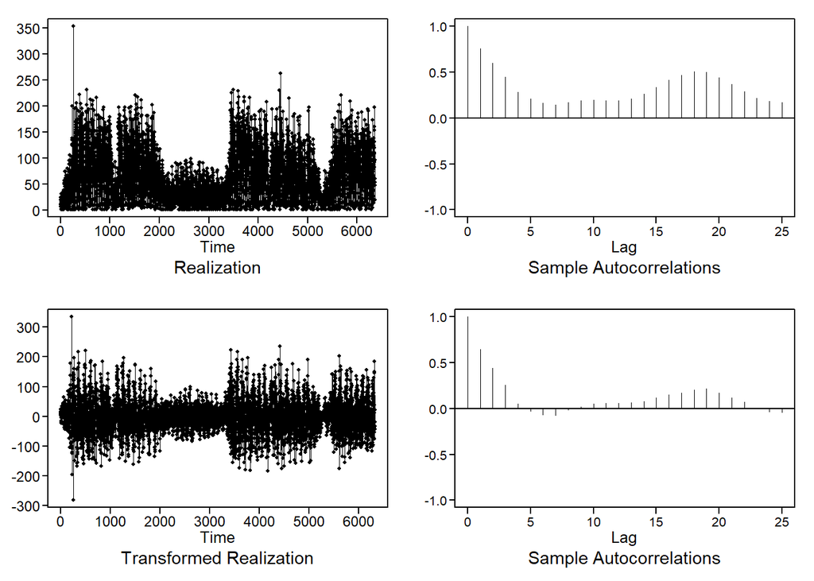

```r
# y is the transformed data
#aic5.wge(y,p=0:15,q=0:6,type='bic')
```

```r
AnonDataTurnstile.est155=est.arma.wge(y,p=15, q=5)
```

```
##
## Coefficients of Original polynomial:
## 1.1952 0.0297 0.0842 0.1868 -1.1691 0.5239 0.0760 0.2168 -0.1971 -0.0113 0.0235 -0.0330 0.0786 -0.0754 0.0318
##
## Factor                 Roots                Abs Recip    System Freq
## 1+0.9670B             -1.0341               0.9670       0.5000
## 1+0.3115B+0.9222B^2   -0.1689+-1.0275i      0.9603       0.2759
## 1-1.8035B+0.8475B^2    1.0641+-0.2186i      0.9206       0.0322
## 1-0.8642B              1.1571               0.8642       0.0000
## 1+0.7733B             -1.2932               0.7733       0.5000
## 1+1.1027B+0.5883B^2   -0.9372+-0.9064i      0.7670       0.3777
## 1-1.3098B+0.5584B^2    1.1729+-0.6444i      0.7472       0.0800
## 1+0.2999B+0.5270B^2   -0.2846+-1.3478i      0.7259       0.2831
## 1-0.6720B+0.3641B^2    0.9229+-1.3765i      0.6034       0.1560
##
##
```

```r
AnonDataTurnstile.est155$phi
```

```
##  [1]  1.19520807  0.02968367  0.08420264  0.18682919 -1.16905561  0.52388739
##  [7]  0.07600246  0.21680204 -0.19709179 -0.01126411  0.02346732 -0.03300892
## [13]  0.07855651 -0.07537803  0.03182909
```

```r
AnonDataTurnstile.est155$theta
```

```
## [1]  0.6139729  0.3021396  0.3046291  0.6236618 -0.9927868
```

```r
AnonDataTurnstile.est155$avar
```

```
## [1] 1474.456
```

```r
mean(AnonDataTurnstile)
```

```
## [1] 63.8022
```

#### Final Seasonal Model

$$(1-B^{36})(1-1.195B-0.0297B^2-0.0842B^3-0.187B^4+1.169B^5-0.524B^6-0.076B^7-0.217B^8+0.197B^9+0.011B^{10}-0.023B^{11}+0.033B^{12}-0.078B^{13}+0.075B^{14}-0.0318B^{15})(X_t-63.8)=(1-0.614B-0.302B^2-0.305B^3-0.624B^4+0.993B^5)a_t\ \sigma^2_a=1474.46$$

```r
seasonFore=fore.aruma.wge(AnonDataTurnstile,phi=c(factAnonData$phi),s=36,n.ahead=48,limits=F)
```

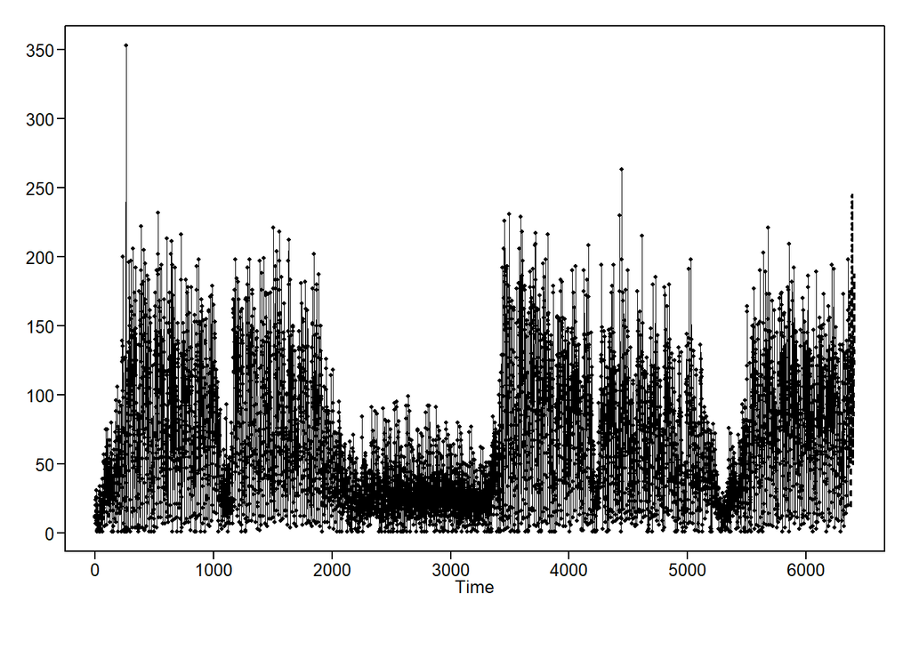

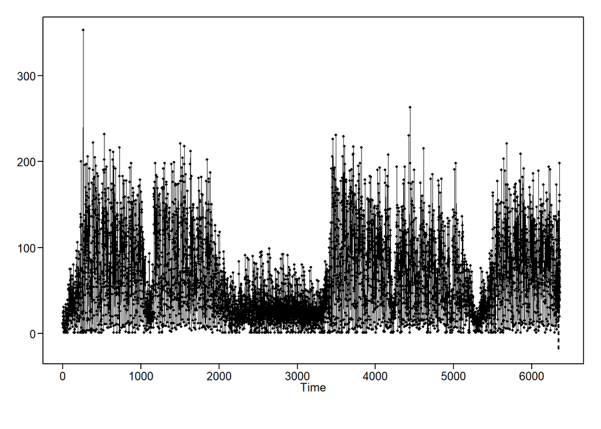

```r
seasonFore$f

fore.aruma.wge(AnonDataTurnstile,phi=c(factAnonData$phi),s=36,n.ahead=48,plot=T,lastn=T,limits=F)
```

Trying the forecasting package on the hourly data

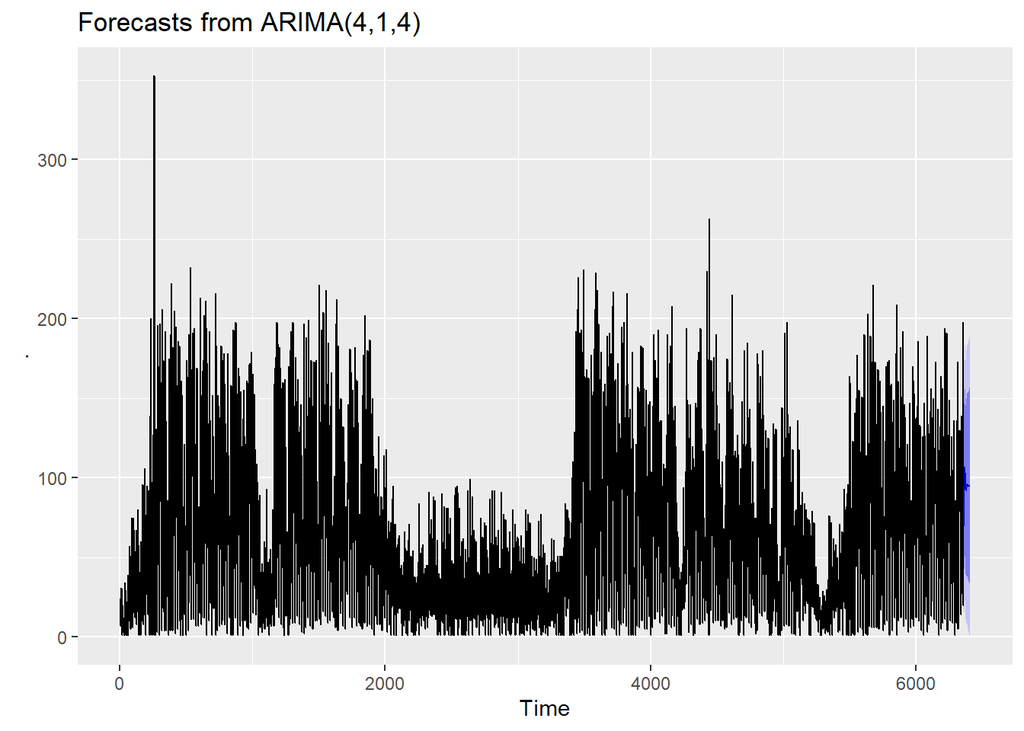

```r
#Trying the forcasting package
AnonDataTurnstile.f = auto.arima(AnonDataTurnstile, stepwise=FALSE, approximation=FALSE, stationary = FALSE, seasonal = TRUE, trace = FALSE,max.p = 13,max.q = 5,max.P = 13,max.Q = 5)

HourForcast=forecast(AnonDataTurnstile.f, h=48, level = 95)
# Automatic ARIMA forecasts
AnonDataTurnstile %>%
  auto.arima() %>%
  forecast(h=48) %>%
  autoplot()
```